# History of Philosophy

Xiangyi Yan

2/6/2023

[figure not shown]

## Introduction

Philosophy has been a central discipline in human history, serving as a means of exploring the fundamental questions of existence, morality, and meaning. From ancient Greek philosophers such as Socrates, Plato, and Aristotle, to modern thinkers such as Immanuel Kant, Friedrich Nietzsche, and Martin Heidegger, the discipline has played a crucial role in shaping our understanding of the human condition. Through careful examination and reflection, philosophy has helped us to gain insights into the nature of reality, our place in the world, and the ways in which we interact with one another. Therefore, it’s significant to explore their philosophical focuses to shape our world more clearly and how the central mind evolves through time.

## Data Description

```r
dat <- read.csv("philosophy_data.csv", head = T)
dim(dat)
```

```
## [1] 360808     11
```

```r
names(dat)
```

```
##  [1] "title"                     "author"
##  [3] "school"                    "sentence_spacy"
##  [5] "sentence_str"              "original_publication_date"
##  [7] "corpus_edition_date"       "sentence_length"
##  [9] "sentence_lowered"          "tokenized_txt"
## [11] "lemmatized_str"
```

```r
head(dat)
```

```
##                    title author school
## 1 Plato - Complete Works  Plato  plato
## 2 Plato - Complete Works  Plato  plato
## 3 Plato - Complete Works  Plato  plato
## 4 Plato - Complete Works  Plato  plato
## 5 Plato - Complete Works  Plato  plato
## 6 Plato - Complete Works  Plato  plato
##                                                                                                                  sentence_spacy
## 1  What's new, Socrates, to make you leave your usual haunts in the Lyceum and spend your time here by the king archon's court?
## 2                                                         Surely you are not prosecuting anyone before the king archon as I am?
## 3                                                    The Athenians do not call this a prosecution but an indictment, Euthyphro.
## 4                                                                                                         What is this you say?
## 5                         Someone must have indicted you, for you are not going to tell me that you have indicted someone else.
## 6                                                                                            But someone else has indicted you?
##                                                                                                                    sentence_str
```

[output cut: 34 more lines]

```r
summary(dat)
```

```
##     title              author             school          sentence_spacy
##  Length:360808      Length:360808      Length:360808      Length:360808
##  Class :character   Class :character   Class :character   Class :character
##  Mode  :character   Mode  :character   Mode  :character   Mode  :character
##
##
##
##  sentence_str       original_publication_date corpus_edition_date
##  Length:360808      Min.   :-350              Min.   :1887
##  Class :character   1st Qu.:1641              1st Qu.:1991
##  Mode  :character   Median :1817              Median :2001
##                     Mean   :1327              Mean   :1995
##                     3rd Qu.:1949              3rd Qu.:2007
##                     Max.   :1985              Max.   :2016
##  sentence_length  sentence_lowered   tokenized_txt      lemmatized_str
##  Min.   :  20.0   Length:360808      Length:360808      Length:360808
##  1st Qu.:  75.0   Class :character   Class :character   Class :character
##  Median : 127.0   Mode  :character   Mode  :character   Mode  :character
##  Mean   : 150.8
##  3rd Qu.: 199.0
##  Max.   :2649.0
```

```r
attach(dat)
```

The dataset (Alizadeh, 2021) contains over 360k sentences from over 50 texts spanning 13 significant schools of philosophy. Of the 11 variables, 8 are categorical, and 3 are continuous. The dataset is complete and clean and does not have any rows with missing data.

From the summary table above, we can see that the data contains philosophical books from 350 BC to 1985, where most books were published in modern times and edited recently. When writing a book, philosophers tend to control a sentence length of around 151 to make the book more readable. Take a glance at the dataset from the histograms of the quantitative variables below:

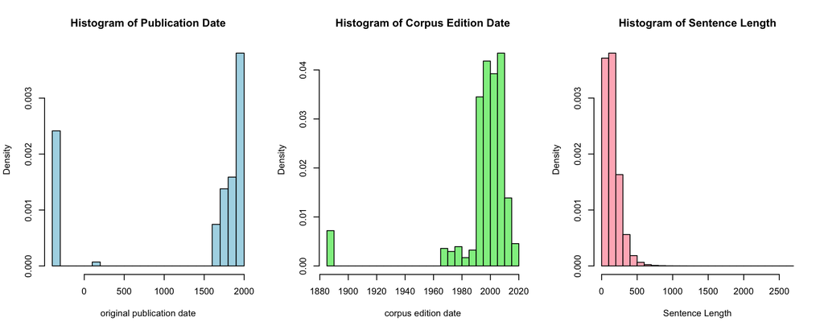

```r
par(mfrow=c(1,3))
date <- dat$original_publication_date
hist(date, freq=F, right=F, col="lightblue",
     xlab="original publication date",
     main="Histogram of Publication Date")

hist(corpus_edition_date, freq=F, right=F, col="lightgreen",
     xlab="corpus edition date",
     main="Histogram of Corpus Edition Date")

hist(sentence_length, freq=F, right=F, col="lightpink",
     xlab="Sentence Length",
     main="Histogram of Sentence Length")
```

## Finding Relationships

After perceiving some information about the dataset, we dug deeper into the variables to see if there’s any relationship between them. The $original\ date\ of\ publications$ (original_publication_date), the $length\ of\ sentences$ (sentence_length), and various $types\ of\ schools$ (school) were what we focused on.

First, I was curious about whether or not the time period affects the sentence length. However, the plot does not show a strong correlation between them:

```r
plot(date, sentence_length, col = "skyblue",
     main="Time Period vs. Sentence Length", xlab="Year",
     ylab="Sentence Length", pch=19)
cor(date, sentence_length)
```

```
## [1] 0.06739653
```

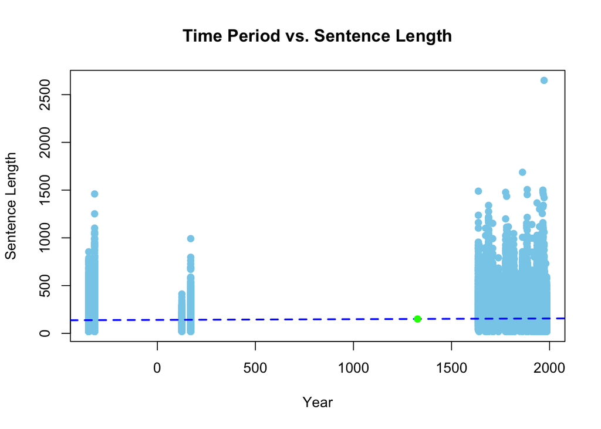

```r
m1 <- lm(sentence_length ~ date)
abline(m1, lty=2, lwd=2, col="blue")
points(mean(date), mean(sentence_length),
       pch=19, col="green")
```

A correlation of 0.06739653 is too weak to conclude a relationship. Also, the SLR fitted above has a large fitness error with the dataset.

Then, I wondered what other variables might affect the sentence lengths. Take a look at the type of schools we have in the dataset, which are:

```r
levels(factor(school))
```

```
##  [1] "analytic"        "aristotle"       "capitalism"      "communism"
##  [5] "continental"     "empiricism"      "feminism"        "german_idealism"
##  [9] "nietzsche"       "phenomenology"   "plato"           "rationalism"
## [13] "stoicism"
```

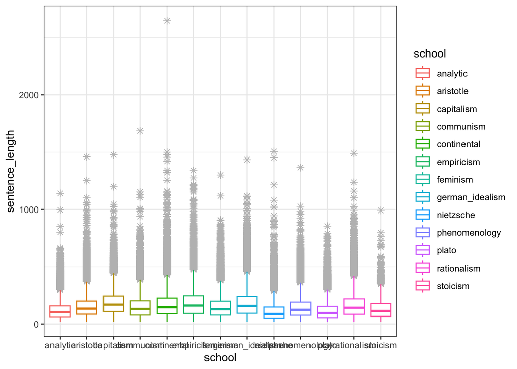

```r
ggplot(data=dat, mapping = aes(x = school, y = sentence_length, col = school)) +
  geom_boxplot(outlier.colour="grey", outlier.shape=8, outlier.size=2) +
  theme_bw()
```

At last, I moved my attention to the time period of each school’s popularity.

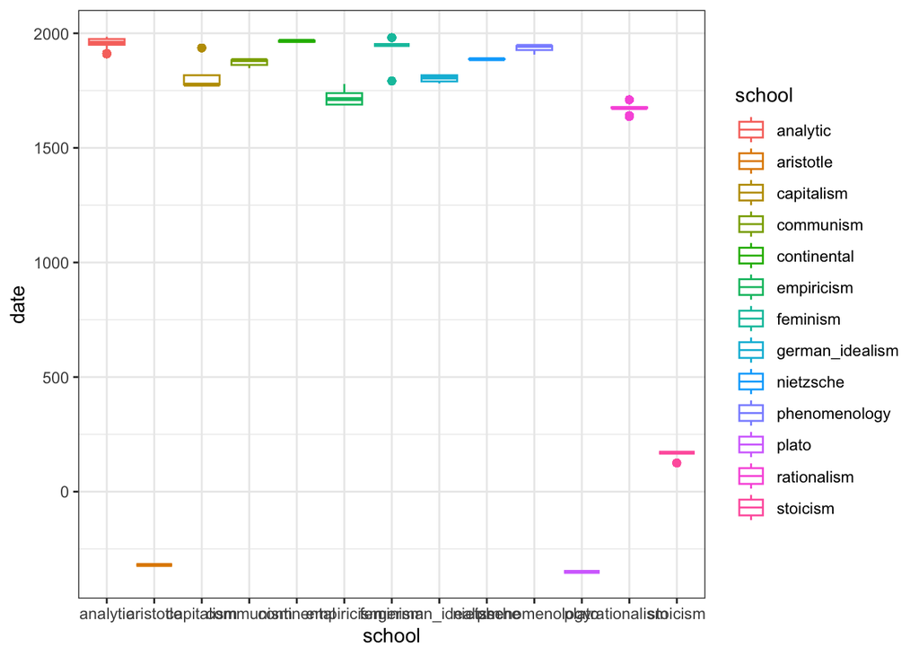

```r
ggplot(data=dat, mapping = aes(x = school, y = date, col = school)) +
  theme(axis.text = element_text(size = 10)) +
  geom_boxplot() +
  theme_bw()
```

## Main Focus of Philosophers and Their Frequent Words

The history of philosophy is rich and spans a significant period of time, encompassing a diverse array of perspectives, beliefs, and theories. Every philosopher has their own unique point of view and area of specialization, which they used to explore and understand the world around them. This has resulted in a rich tapestry of philosophical thought, covering various subjects such as ethics, politics, metaphysics, epistemology, and much more. To gain a deeper understanding of the role that philosophy has played in shaping society, it is necessary to carefully study the most representative philosophers from different time periods. By doing this, we can gain insight into the evolution of philosophical thought and the impact that it has had on the world.

First, we need to know which philosophers are included in the dataset.

```r
levels(factor(author))
```

```
##  [1] "Aristotle"       "Beauvoir"        "Berkeley"        "Davis"
##  [5] "Deleuze"         "Derrida"         "Descartes"       "Epictetus"
##  [9] "Fichte"          "Foucault"        "Hegel"           "Heidegger"
## [13] "Hume"            "Husserl"         "Kant"            "Keynes"
## [17] "Kripke"          "Leibniz"         "Lenin"           "Lewis"
## [21] "Locke"           "Malebranche"     "Marcus Aurelius" "Marx"
## [25] "Merleau-Ponty"   "Moore"           "Nietzsche"       "Plato"
## [29] "Popper"          "Quine"           "Ricardo"         "Russell"
## [33] "Smith"           "Spinoza"         "Wittgenstein"    "Wollstonecraft"
```

```r
date[author=="Plato"][1]
```

```
## [1] -350
```

```r
date[author=="Aristotle"][1]
```

```
## [1] -320
```

```r
date[author=="Kant"][1]
```

```
## [1] 1788
```

```r
date[author=="Nietzsche"][1]
```

```
## [1] 1888
```

```r
date[author=="Heidegger"][1]
```

```
## [1] 1927
```

Plato, Aristotle, Kant, Nietzsche, and Heidegger are five of the most influential philosophers in Western philosophy, the front two were from ancient times and the latter three were in modern times, each making important contributions to the field and expanding our understanding of the world. Thus it’s important for us to discover what their ideas emphasize.

Plato was a student of Socrates and is best known for his theory of Forms, in which he believed that reality was comprised of eternal, unchanging Forms or Ideas, of which the physical world is just a reflection. He also founded the Academy in Athens, which was one of the first institutions of higher learning in the Western world.

```r
p <- subset(dat, author == "Plato")
strings <- p$tokenized_txt

# Split each string into words
words_list <- unlist(lapply(strings, function(string) {
  strsplit(string, " ")[[1]]
}))
# Create a table of word frequencies
word_table <- table(words_list)
# Sort the word frequency table in decreasing order
table1 <- sort(word_table, decreasing=TRUE)
dim(table1)
```

```
## [1] 25505
```

```r
table1[50:200]
```

```
## words_list
##        'has',       'must',     'should',        'our',         'me',
##          2239          2226          2153          2134          2133
##        'any',       'same',       'than',        'man',       'good',
##          2106          2018          2016          2012          1998
##      'there',        'him',       'said',         'no',      'think',
##          1955          1921          1913          1895          1876
##       'were',         'an',      'those',       'just',         'us',
##          1876          1844          1832          1827          1809
##       ['the',       'more',        'way',       'your',        'can',
##          1719          1714          1668          1642          1638
##       'some',         'my',        ['so',     'people',       'like',
##          1635          1616          1586          1578          1524
##      'thing',      'being',        'its',        'now',       'each',
##          1466          1448          1434          1406          1357
##       'know',       'such',    'because',        'had',       'make',
##          1340          1320          1302          1292          1261
##   'socrates',       'most',        ['it',        'how',  'something',
##          1239          1230          1228          1213          1207
##      ['then',       'been',        'out',       'into',       'also',
##          1175          1160          1160          1136          1129
##       'both',        'men',         'up',       'even',       'only',
##          1097          1091          1091          1076          1065
##        ['if',       'soul',       'many',         'it']      ['that',
##          1056          1051          1046          1033           995
##        'don',        'own',       'does',        'two',      'could',
##           989           985           984           969           962
##         'll',    'whether',       'time',       'well',         're',
##           952           941           933           931           929
##        'see',      ['what',       'very',      'right',       'come',
##           916           915           911           906           889
##       'take',       ['you',      ['well',       ['now',      'first',
##           879           879           874           868           860
##     'others',       'kind',       'city',       'part',  'knowledge',
##           858           845           812           810           809
##        ['we',     'itself',        'let',    'someone',      'since',
##           800           799           797           773           768
##       'give',         've',        ['in',     'anyone',       'life',
##           758           747           747           740           732
##       'sort',   'anything',    'another',       ['for',       'call',
```

[output cut: 8 more lines]

```
##           651           646           644           643           643
##      'every',         'go',       'much',      'seems',     'nature',
##           642           633           631           625           623
##       'true',       'over',       'name',     'before',       'best',
##           622           610           605           604           604
##    'through',        'bad',     'either',      'never',      'after',
##           604           598           593           592           586
##     'always',      'point',      'whole',        'god',     'saying',
##           580           578           562           557           542
##        'did',      ['they',     'really',        'put',       'fact',
##           540           538           532           529           525
##       'love',     'virtue',       'find',       'here', 'themselves',
##           523           521           519           512           510
##        ['or',
##           494
```

Except for common words that we usually use in normal circumstances, I found the most frequent word of “think” 1876 times, “being” 1448 times, “soul” 1051 times, “own” 985 times, “knowledge” 809 times, “gods” 710 times, which play an important role in verifying his idea.

Aristotle was a student of Plato and a tutor to Alexander the Great. He rejected Plato’s theory of Forms and instead believed that the physical world was the ultimate reality. He made important contributions to a wide range of fields, including ethics, politics, metaphysics, and biology.

```r
a <- subset(dat, author == "Aristotle")
strings <- a$tokenized_txt


words_list <- unlist(lapply(strings, function(string) {
  strsplit(string, " ")[[1]]
}))
word_table <- table(words_list)
table2 <- sort(word_table, decreasing=TRUE)
dim(table2)
```

```
## [1] 29815
```

```r
table2[40:200]
```

```
## words_list
##         'he',       'must',         'on',       'then',      'these',
##          4559          4458          4319          4298          4180
##     'things',       'also',        'its',         'an',      'being',
##          4172          4035          4033          3900          3820
##       'them',        'man',       'more',         'no',    'because',
##          3795          3794          3791          3726          3642
##        'who',       'than',      'those',       ['but',         'do',
##          3634          3623          3548          3300          2946
##       'such',       'does',      'thing',       'only',        'any',
##          2901          2745          2667          2634          2572
##     'should',       'both',        'can',       ['and',        'may',
##          2534          2533          2471          2441          2427
##       'been',       'good',       'into',    'animals',        'two',
##          2394          2382          2287          2268          2208
##       'case',     'either',        'his',       'time',       'like',
##          2201          2161          2105          2084          2061
##       'part',      'would',        ['it',        'say',    'another',
##          2048          2015          2002          2001          1941
##  'something',      'while',      'first',        'way',       'body',
##          1939          1930          1872          1810          1799
##     'nature',       'each',     'others',     'motion',      'since',
##          1799          1788          1752          1719          1717
##       'said',      'parts',      'about',        'was',      'water',
##          1711          1696          1646          1617          1611
##       'most',        'nor',       'many',        'too',     'reason',
##          1608          1583          1558          1552          1541
##      'every',       'even',        'our',        'out',  'therefore',
##          1497          1489          1489          1485          1481
##       'were',        ['in',       'just',        'men',     'cannot',
##          1473          1470          1462          1410          1408
##      'place',       ['now',       'kind',      ['this',      'sense',
##          1408          1396          1388          1387          1366
##        ['if',         'eg',     'always',    'without',   'possible',
##          1355          1346          1339          1325          1308
##    'whether',        'you',         'up',     'called',     'itself',
##          1297          1269          1262          1259          1257
##     'belong',     'though',     'animal',     'number',        'air',
##          1211          1185          1180          1178          1176
##    'through',        'why',       'come',       'true',   'movement',
```

[output cut: 12 more lines]

```
##           914           914           913           907           902
##        ['so',  'necessary',       'made',      'cases',    'natural',
##           898           894           881           876           874
##        'own',     'change',      'right',        'now',     ['again',
##           872           866           866           864           862
##  'substance', 'themselves',       'soul',       'take',     'before',
##           857           855           853           852           831
##        'him',        'yet',      'found',       'much',      'comes',
##           830           826           818           815           810
##     'causes',   'property',   'anything',    'thought',       'else',
##           800           795           789           778           777
##    'however',      'where',      'small',      'great',    'greater',
##           777           776           772           769           763
##       'upon',
##           753
```

Again, I picked the usable nouns from the table above and saw “being” 3820 times, “animals” 2268 times, “time” 2084 times, “body” 1799 times, “nature” 1799 times, “motion” 1719 times, “water” 1611 times, where all come from reality.

Kant was an 18th-century German philosopher who sought to reconcile the conflicting ideas of empiricism and rationalism. He believed that the mind imposes structure on our experiences and that our knowledge of the world is limited by the nature of our perceptual and cognitive faculties.

```r
k <- subset(dat, author == "Kant")
strings <- k$tokenized_txt


words_list <- unlist(lapply(strings, function(string) {
  strsplit(string, " ")[[1]]
}))
word_table <- table(words_list)
table3 <- sort(word_table, decreasing=TRUE)
dim(table3)
```

```
## [1] 18080
```

```r
table3[1:150]
```

```
## words_list
##            'the',             'of',             'to',             'in',
##             30980             26443             13342             12201
##             'is',            'and',           'that',             'as',
##             10292              9488              7874              6888
##             'it',             'be',          'which',           'this',
##              6121              5491              5392              4390
##            'not',            'for',           'with',             'an',
##              4215              3958              3596              3106
##            'its',            'all',             'we',           'from',
##              2998              2815              2744              2695
##            'but',           'only',            'one',            'can',
##              2649              2629              2545              2481
##            'are',             'by',             'or',         'reason',
##              2474              2303              2274              2261
##             'on',        'concept',            'our',           ['the',
##              1956              1880              1732              1699
##          'would',         'nature',           'have',             'if',
##              1667              1657              1655              1496
##         'object',             'at',             'no',           'must',
##              1485              1481              1440              1439
##           'pure',        'through',           'they',           'such',
##              1386              1366              1352              1307
##          'their',         'itself',           'even',          'being',
##              1287              1273              1229              1215
##           'also',             'so',           ['but',            'has',
##              1179              1148              1139              1133
##         'merely',  'understanding',            'any',       'possible',
##              1127              1098              1094              1079
##           'what',           'then',       'concepts',             'us',
##              1068              1034              1027              1005
##         'priori',           ['for',          'given',          'other',
##               995               991               957               949
##           'will',          'these',      'empirical',     'experience',
##               945               943               938               925
##      'cognition',         'cannot',      'judgement',           'them',
##               914               912               898               893
##           'time',         'things',          'there',        'without',
##               873               854               844               839
##      'intuition',        'objects',      'principle',            'may',
```

[output cut: 22 more lines]

```
##               555               555               552               549
##            'end',        'natural',          'order',          ['this',
##               548               541               539               525
##         'rather',           'idea',      'condition',     'conditions',
##               513               511               510               510
##          'never',           'case',         'latter',          'power',
##               508               506               503               498
##          'sense',            'own',            ['it',          'about',
##               498               497               496               494
##       'relation',        'subject',        'whether',        'thought',
##               494               489               488               486
##         'ground',      'according',          'human',           'here',
##               485               484               484               482
##        'faculty',           'upon',
##               479               479
```

Similarly, I found “reason” 2261 times, “concept” 1880 times (and “concepts” 1027 times), “nature” 1657 times, “object” 1485 times, “being” 1215 times, “understanding” 1098 times, where all of them are the basic of cognition.

Nietzsche was a 19th-century German philosopher who rejected the traditional values and beliefs of his time and instead espoused a philosophy of life that celebrated individuality, creativity, and the will to power. He is best known for his ideas about the death of God and the rejection of traditional morality.

```r
n <- subset(dat, author == "Nietzsche")
strings <- n$tokenized_txt


words_list <- unlist(lapply(strings, function(string) {
  strsplit(string, " ")[[1]]
}))
word_table <- table(words_list)
table4 <- sort(word_table, decreasing=TRUE)
dim(table3)
```

```
## [1] 18080
```

```r
table4[1:150]
```

```
## words_list
##         'the',          'of',         'and',          'to',          'is',
##          15677          11313           8925           7395           5190
##          'in',        'that',          'it',         'for',          'as',
##           4566           3626           3077           2336           2312
##         'not',       'which',         'all',          'be',          'he',
##           2118           2092           2048           1987           1788
##        'with',         'one',        'this',         'his',        'have',
##           1783           1674           1610           1526           1437
##          'my',         'are',        ['the',        'they',          'at',
##           1358           1328           1291           1210           1136
##         'was',         'who',        'from',          'an',          'on',
##           1095           1092           1033           1020           1005
##         'has',       'their',        'will',          'by',         'man',
##            973            951            929            927            911
##          'me',         'its',        ['and',        'more',         'but',
##            883            853            852            836            809
##        'only',          'or',       'there',          'no',        'even',
##            798            791            779            767            766
##        'what',        'thou',          'do',          'we',          'so',
##            716            709            674            651            639
##        'been',        'also',        'most',        'must',         'him',
##            627            616            616            609            593
##        'when',       'would',        'into',          'ye',        ['but',
##            586            582            573            567            561
##         'had',        'such',        'them',        'life',       'every',
##            559            551            550            534            525
##        'good',        'than',         ['it',        'like',      'itself',
##            508            494            490            486            478
##       'great',         'god',         'out', 'zarathustra',      'things',
##            475            473            470            455            449
##     'however',       'still',         'did',         'our',       'world',
##            442            442            438            433            418
##         'any',        'upon',          'if',         'you',         'may',
##            411            409            406            402            394
##     'himself',        'your',         ['in',         'how',         'thy',
##            388            386            384            379            373
##        'then',       'those',         'men',        'hath',         'say',
##            371            369            368            367            366
##        'unto',       'first',         'can',         'now',          'us',
##            356            348            347            345            344
##        'time',        'were',      'people',        'love',       'other',
##            337            337            336            335            329
##         'too',       'these',        'self',      'should',      'spirit',
##            325            324            323            318            309
##         'own',        'much',        'ever',         ['he',         'day',
##            307            305            300            299            298
##       ['this',      'become',        'very',     'against',  'everything',
##            294            291            290            287            287
##       'means',         'old',        'last',          'up',       'about',
##            285            284            279            277            276
##        'long',        ['for',       'whole',         ['to',      'always',
##            274            274            273            273            272
##          'it']        'does',         'new',        'once',        'fact',
##            270            269            269            268            266
##        'over',   'something',       'could',  'themselves',        'soul',
##            264            264            262            262            260
##        'thee',        'thus',        'many',        'know',       ['what',
##            260            258            252            249            248
##       'order',       'shall',      'german',        'here',        'said',
##            243            241            239            237            235
```

Nietzsche, in our data, repeatedly used “he” 1788 times, “life” 534 times, “god” 473 times, “zarathustra” 455 times, “world” 418 times, which point to God and nonnormality of the society.

Heidegger was a 20th-century German philosopher who is best known for his work “Being and Time”. He sought to understand the nature of being and focused on the idea of “Being-towards-Death”, which he believed was a fundamental aspect of human existence.

```r
h <- subset(dat, author == "Heidegger")
strings <- h$tokenized_txt

words_list <- unlist(lapply(strings, function(string) {
  strsplit(string, " ")[[1]]
}))
word_table <- table(words_list)
table5 <- sort(word_table, decreasing=TRUE)
dim(table5)
```

```
## [1] 18166
```

```r
table5[1:150]
```

```
## words_list
##            'the',             'of',             'is',             'in',
##             22620             17567              9683              8583
##             'to',            'and',           'that',          'being',
##              7045              6045              4906              4393
##             'as',             'it',          'which',           'this',
##              4272              3905              2839              2674
##           ['the',            'its',            'not',             'be',
##              2639              2623              2565              2319
##           'what',         'itself',            'for',           'with',
##              2026              2012              1887              1869
##             'we',            'has',         'dasein',           'from',
##              1800              1510              1504              1344
##             'an',            'are',             'by',             'at',
##              1339              1336              1288              1240
##          'world',           'only',            'can',         'beings',
##              1202              1200              1051              1029
##            'but',           'into',           'does',            'way',
##               929               910               890               885
##            'one',           'time',           ['but',             'on',
##               859               855               843               830
##      'something',            ['in',             'or',            'all',
##               795               794               772               748
##           'such',           'have',           'must',          ['this',
##               743               731               714               705
##            ['it',        'present',             'da',        'already',
##               693               664               656               626
##         'things',           'will',          'truth',           'been',
##               624               599               578               577
##            'out',           'they',        'essence',          'means',
##               571               570               569               565
##           'more',          'about',             'if',           'care',
##               561               560               559               557
##  'understanding',          'first',            'our',         'always',
##               557               535               522               519
##    'ontological',          'their',  'consciousness', 'interpretation',
##               500               498               494               493
##           'self',          'there',             'so',          'being']
##               491               487               486               463
##           'work',           'also',           'kind',    'existential',
```

[output cut: 22 more lines]

```
##               298               295               293               293
##            'his',            'who',            'any',           'most',
##               290               288               284               284
##   'potentiality',          'death',          'terms',         'taking',
##               284               283               280               279
##            ['if',           'than',        'concept',    'fundamental',
##               276               275               273               273
##            'was',           'call',            ['as',             'do',
##               273               270               265               264
##        'through',          'taken',            'yet',          ['that',
##               264               263               263               258
##        'becomes',     'understood',    'temporality',         'nature',
##               254               251               246               244
##        'science',      'structure',
##               244               243
```

These are just a few of the differences between the ideas of these five philosophers, but each one has made important contributions to the field of philosophy and has had a lasting impact on our understanding of the world.

## Conclusions

It is worth noting that before 1750, philosophers were often limited by the technology and resources available to them. However, with the advent of new technologies and increased resources, more philosophers were able to emerge and their ideas were able to flourish. This has led to a rich and diverse landscape of philosophical thought, with a wide range of schools, theories, and perspectives.

The fact that there is no clear relationship between sentence length and publication date, or sentence length and school type, highlights the complex and multi-faceted nature of the philosophical inquiry. Philosophy is a constantly evolving discipline, with new ideas and perspectives emerging all the time. It is this dynamic and constantly evolving nature that makes philosophy such an exciting and rewarding field of study.